# Data 612 - Project 2

Paul Perez

6/16/2020

## The Recommender System’s

This recommender system uses the `recommenderlab` package, and we’ll load the MovieLense dataset. We can see that using the `class()` function, that this MovieLense dataset is a `realRatingMatrix`.

## Data Ingestion, Selection, Manipulation

```r
data("MovieLense")
class(MovieLense)
```

```
## [1] "realRatingMatrix"
## attr(,"package")
## [1] "recommenderlab"
```

```r
matrix <- as(MovieLense, "realRatingMatrix")
```

## Data Exploration

Using the `dim()` function, we can see the dimensions of the MovieLense matrix.

```r
dim(matrix)
```

```
## [1]  943 1664
```

There are `943` users and `1664` movies.

### Similarity Matrix (User & Item)

The similarity matrix measures the similarity between item’s or user’s within the matrix. For the purpose of this project, we’ll use the `cosine` method.

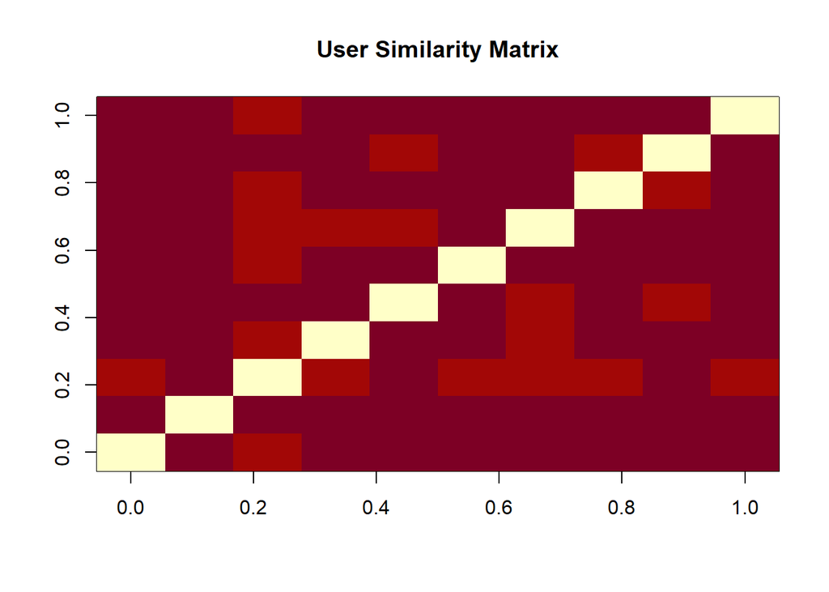

```r
user_simularity <- similarity(matrix[1:10, ], method = "cosine", which = "users")
image(as.matrix(user_simularity), main = "User Similarity Matrix")
```

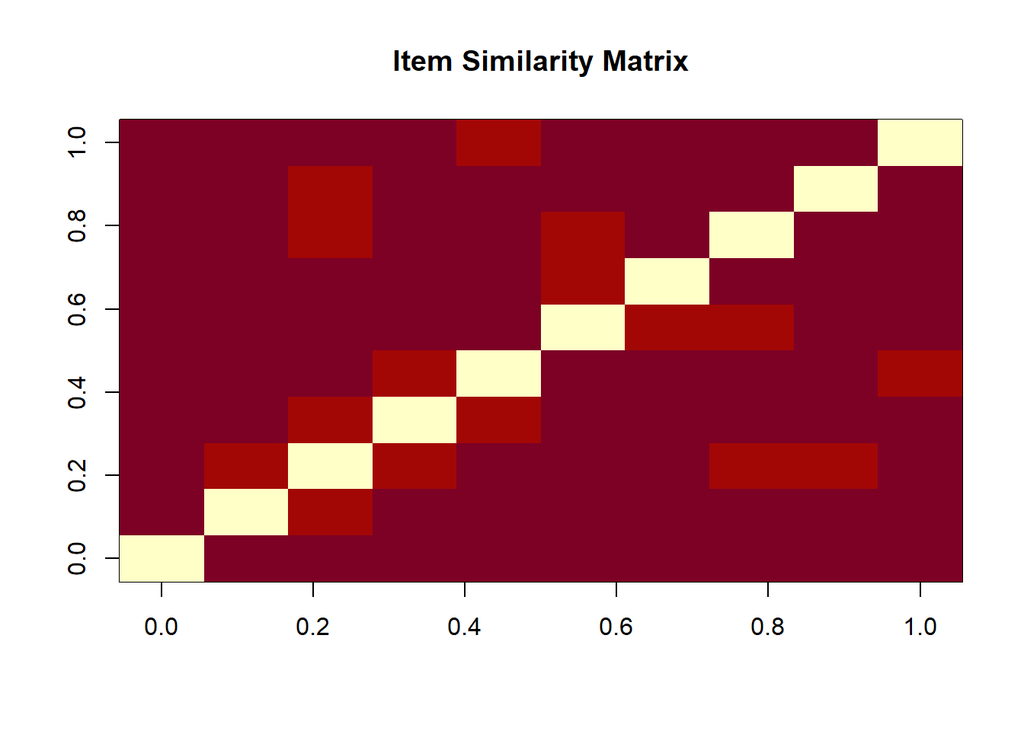

```r
item_similarity <- similarity(matrix[, 1:10], method = "cosine", which = "items")
image(as.matrix(item_similarity), main = "Item Similarity Matrix")
```

There are some emperical studies that show greater performance with the `cosine` similarity method for item based recommendation systems where the `pearson` similarity method shows greater performance for user based recommendation systems.

Since we loaded the data as a `realRatingMatrix`, which is an S4 class, we can look further into components of the object using `slotNames()`

```r
slotNames(matrix)
```

```
## [1] "data"      "normalize"
```

By adding `@data` to the `matrix` object, we’ll be able to take a look at this class, which happens to be a `dgCMatrix` class that inherits from the original matrix.

```r
class(matrix@data)
```

```
## [1] "dgCMatrix"
## attr(,"package")
## [1] "Matrix"
```

By converting the ratings to a vector, we can count the number of unique ratings available.

```r
vector_ratings <- as.vector(matrix@data)
table_ratings <- table(vector_ratings)
table_ratings %>% kable(caption = "Item Similarity Table") %>% kable_styling("striped", full_width = TRUE)
```

| vector_ratings | Freq |
| --- | --- |
| 0 | 1469760 |
| 1 | 6059 |
| 2 | 11307 |
| 3 | 27002 |
| 4 | 33947 |
| 5 | 21077 |

We can look at the distribution of ratings.

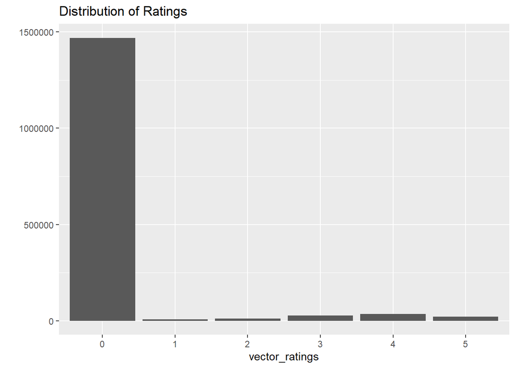

```r
vector_ratings <- factor(vector_ratings)
qplot(vector_ratings) + ggtitle("Distribution of Ratings")
```

### Select Relevant Data

```r
movie_ratings <- matrix[rowCounts(matrix) > 95, colCounts(matrix) > 50]
dim(movie_ratings)
```

```
## [1] 369 591
```

### Top 1% of Users

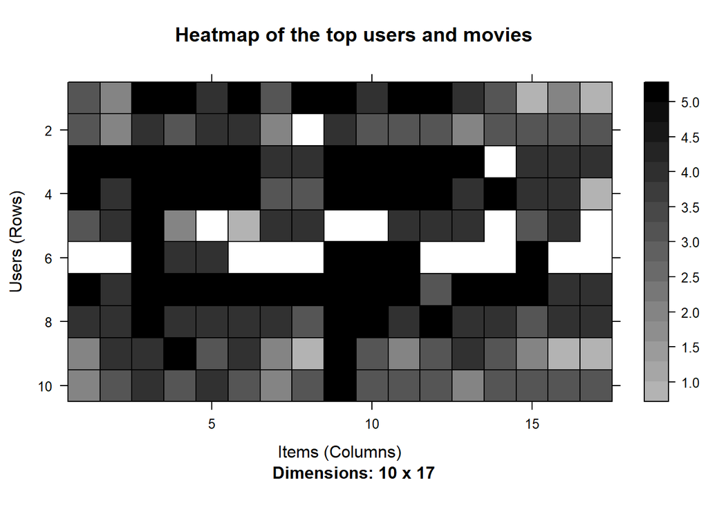

```r
min_movies <- quantile(rowCounts(matrix, na.rm = TRUE), 0.99)
min_users <- quantile(colCounts(matrix, na.rm = TRUE), 0.99)
image(matrix[rowCounts(matrix) > min_movies, colCounts(matrix) > min_users], main = "Heatmap of the top users and movies")
```

### Distribution of Average Rating by User

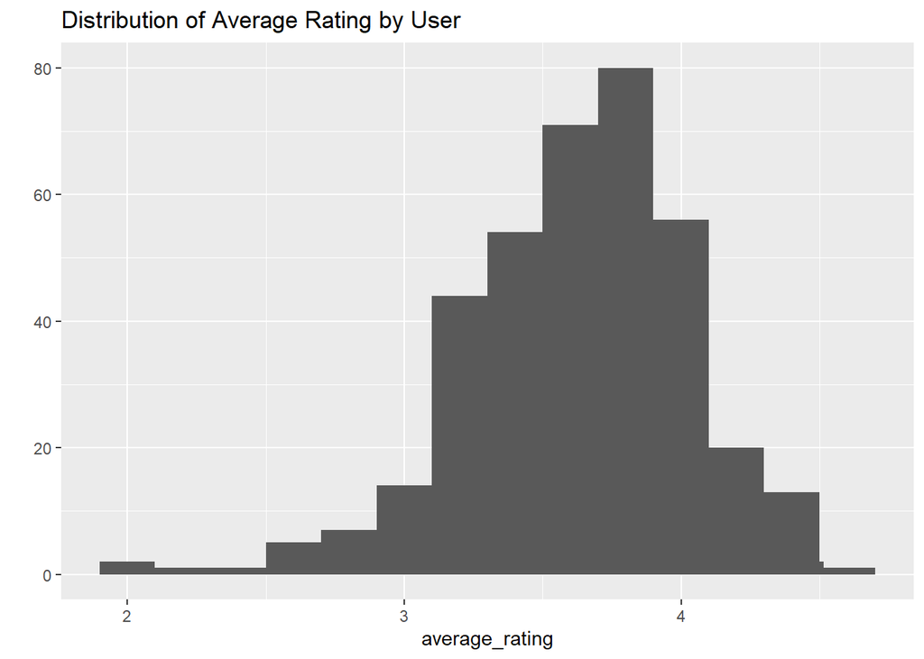

```r
average_rating <- rowMeans(movie_ratings)
qplot(average_rating) + stat_bin(binwidth = 0.2) + ggtitle ("Distribution of Average Rating by User")
```

## Split into Training & Test datasets using an 80/20 Ratio

```r
set.seed(123)
train_sample <- sample(x = c(TRUE, FALSE), size = nrow(movie_ratings), replace = TRUE, prob = c(0.8, 0.2))
movie_train <- movie_ratings[train_sample,]
movie_test <- movie_ratings[!train_sample,]
```

## Item-Item Collaborative Filtering

This method identifies which items were similar in terms of other’s items closely related.

#### Create the Item-Item Collaborative Filter Recommender System with the training set

```r
item_model <- Recommender(movie_train, method = "IBCF")
item_model
```

```
## Recommender of type 'IBCF' for 'realRatingMatrix'
## learned using 300 users.
```

#### Predict the Item-Item Collaborative Filter Recommender System on the test set

```r
item_predict <- predict(item_model, movie_test, n = 5)
```

Let’s produce a list of the top 5 movie recommendations based on the Item-Item Collaborative Filter Recommender System.

```r
item_reco_user_1 <- item_predict@items[[1]]
item_movie_user_1 <- item_predict@itemLabels[item_reco_user_1]
item_movie_user_1 %>% kable(caption = "User 1 Recommendations: Item-Item") %>% kable_styling("striped", full_width = TRUE)
```

User 1 Recommendations: Item-Item

| x |
| --- |
| Six Degrees of Separation (1993) |
| While You Were Sleeping (1995) |
| Man Who Knew Too Little, The (1997) |
| Othello (1995) |
| Space Jam (1996) |

## User-User Collaborative Filtering

This method identifies similar user’s to show close relations between the different users.

```r
user_model <- Recommender(movie_train, method = "UBCF")
user_model
```

```
## Recommender of type 'UBCF' for 'realRatingMatrix'
## learned using 300 users.
```

#### Predict the User-User Collaborative Filter Recommender System on the test set

```r
user_predict <- predict(user_model, movie_test, n = 5)
```

Let’s produce a list of the top 5 movie recommendations based on the User-User Collaborative Filter Recommender System.

```r
user_reco_user_1 <- user_predict@items[[1]]
user_movie_user_1 <- user_predict@itemLabels[user_reco_user_1]
user_movie_user_1 %>% kable(caption = "User 1 Recommendations: User-User") %>% kable_styling("striped", full_width = TRUE)
```

User 1 Recommendations: User-User

| x |
| --- |
| Titanic (1997) |
| Good Will Hunting (1997) |
| Much Ado About Nothing (1993) |
| This Is Spinal Tap (1984) |
| Apt Pupil (1998) |

## Summary

#### Source Code

[GitHub Repository](https://github.com/ChefPaul/data612/tree/master/Project%202)